# Assignment #1: German Credit

Luke Schwenke

2023-01-22

# Regression Model

```r
df <- GermanCredit
df <- df %>% dplyr::select(-Class) # Remove Class variable

full_model <- lm(Amount ~ ., data=df)

# Save and Print Coefficients
full_model_coeff <- full_model$coefficients
full_model_coeff
```

```
##                            (Intercept)                               Duration
##                             6473.24572                              127.22804
##              InstallmentRatePercentage                      ResidenceDuration
##                             -783.07567                              -52.07222
##                                    Age                  NumberExistingCredits
##                                5.75204                               75.35581
##                NumberPeopleMaintenance                              Telephone
##                             -198.28236                             -483.36894
##                          ForeignWorker             CheckingAccountStatus.lt.0
##                             -249.97139                             -104.08052
##         CheckingAccountStatus.0.to.200           CheckingAccountStatus.gt.200
##                              213.45397                             -614.78718
##             CheckingAccountStatus.none         CreditHistory.NoCredit.AllPaid
##                                     NA                              858.17909
##         CreditHistory.ThisBank.AllPaid                 CreditHistory.PaidDuly
##                              -50.32424                              -15.85221
##                    CreditHistory.Delay                 CreditHistory.Critical
##                              102.78461                                     NA
##                         Purpose.NewCar                        Purpose.UsedCar
##                            -1757.06185                            -1119.30058
##            Purpose.Furniture.Equipment               Purpose.Radio.Television
##                            -1836.09216                            -2071.60201
##              Purpose.DomesticAppliance                        Purpose.Repairs
##                            -2464.06380                            -1707.78133
##                      Purpose.Education                       Purpose.Vacation
##                            -1892.28951                                     NA
##                     Purpose.Retraining                       Purpose.Business
##                            -2209.35799                            -1989.46611
##                          Purpose.Other             SavingsAccountBonds.lt.100
##                                     NA                             -327.00664
##         SavingsAccountBonds.100.to.500        SavingsAccountBonds.500.to.1000
##                             -569.23487                             -643.52855
##            SavingsAccountBonds.gt.1000            SavingsAccountBonds.Unknown
##                             -385.98649                                     NA
##                EmploymentDuration.lt.1              EmploymentDuration.1.to.4
##                              115.35227                               51.82530
##              EmploymentDuration.4.to.7                EmploymentDuration.gt.7
##                              113.35764                             -163.18910
##          EmploymentDuration.Unemployed       Personal.Male.Divorced.Seperated
##                                     NA                              480.33678
##              Personal.Female.NotSingle                   Personal.Male.Single
##                              282.09482                              730.16723
##          Personal.Male.Married.Widowed                 Personal.Female.Single
##                                     NA                                     NA
##            OtherDebtorsGuarantors.None     OtherDebtorsGuarantors.CoApplicant
##                              138.71303                              752.18304
##       OtherDebtorsGuarantors.Guarantor                    Property.RealEstate
##                                     NA                             -840.99813
##                     Property.Insurance                      Property.CarOther
##                             -588.80108                             -570.75237
##                       Property.Unknown             OtherInstallmentPlans.Bank
##                                     NA                             -143.90714
##           OtherInstallmentPlans.Stores             OtherInstallmentPlans.None
##                              -62.89011                                     NA
##                           Housing.Rent                            Housing.Own
##                              243.68008                              131.43220
##                        Housing.ForFree                Job.UnemployedUnskilled
##                                     NA                            -1715.11138
##                  Job.UnskilledResident                    Job.SkilledEmployee
##                            -1198.70995                            -1253.90023
## Job.Management.SelfEmp.HighlyQualified
##                                     NA
```

# Split into Train/Test Sets and Run Model 1,000 times

```r
set.seed(777)

# Create ID to help with splitting into Train/Test
df$id <- 1:nrow(df)

# Initialize empty Data Frame
my_df <- data.frame()

# Run 1,000 Linear models
for(n in 1:1000){

  # Split 63.20% of the data into the train set and the rest into the test set
  train <- df %>% dplyr::sample_frac(0.632)
  test  <- dplyr::anti_join(df, train, by = 'id')

  # Drop id column before running model since it does not have value
  train$id <- NULL
  test$id  <- NULL

  # Run the linear model on all the independent variables
  model <- lm(Amount ~., data=train)

  # Capture the predictions on the Test / Holdout set
  predictions <- predict(model, test)

  # Save the coefficients, and R-squared for the training and holdout
  save_coeff <- model$coefficients
  save_r2_training <- summary(model)$r.squared
  save_r2_holdout <- cor(test$Amount, predict(model, newdata = test))^2

  con <- c(save_coeff, save_r2_training, save_r2_holdout)
  my_df <- rbind(my_df, con)
}

# Remove ID variable and Amount (dependent) variable
df$id <- NULL
df$Amount <- NULL

# Update Column Names
colnames(my_df)[1] <- "(Intercept)"
colnames(my_df)[2:61] <- names(df)
colnames(my_df)[62] <- "training_r2"
colnames(my_df)[63] <- "holdout_r2"

head(my_df, 3)
```

|  | (Intercept) | Duration | InstallmentRatePercentage | ResidenceDuration | Age | NumberExistingCredits | NumberPeopleMaintenance | Telephone | ForeignWorker | CheckingAccountStatus.lt.0 | CheckingAccountStatus.0.to.200 | CheckingAccountStatus.gt.200 | CheckingAccountStatus.none | CreditHistory.NoCredit.AllPaid | CreditHistory.ThisBank.AllPaid | CreditHistory.PaidDuly | CreditHistory.Delay | CreditHistory.Critical | Purpose.NewCar | Purpose.UsedCar | Purpose.Furniture.Equipment | Purpose.Radio.Television | Purpose.DomesticAppliance | Purpose.Repairs | Purpose.Education | Purpose.Vacation | Purpose.Retraining | Purpose.Business | Purpose.Other | … |
| --- | --- | --- | --- | --- | --- | --- | --- | --- | --- | --- | --- | --- | --- | --- | --- | --- | --- | --- | --- | --- | --- | --- | --- | --- | --- | --- | --- | --- | --- | --- |
| 1 | 7053.006 | 132.5061 | -811.3683 | 4.879213 | -3.3883285 | -64.89621 | -276.0670 | -361.8853 | -332.9213 | -145.86101 | 220.0945 | -584.4721 | NA | 962.4469 | -402.1201 | -325.39323 | -248.09909 | NA | -1190.621 | -163.0444 | -1110.880 | -1343.701 | -2101.464 | -1402.828 | -809.9535 | NA | -1437.532 | -1149.776 | NA | … |
| 2 | 8742.704 | 128.5282 | -808.0595 | -125.022627 | 0.4969038 | 117.92245 | -111.0212 | -513.6035 | -139.2039 | 102.85244 | 195.0846 | -677.3200 | NA | 715.3007 | 127.1241 | 107.28357 | 248.44989 | NA | -3616.351 | -2960.3367 | -3900.596 | -3987.831 | -4747.327 | -3527.883 | -3660.1191 | NA | -4200.430 | -3827.898 | NA | … |
| 3 | 6213.055 | 128.2768 | -855.5463 | -7.752832 | -3.5933384 | 159.22881 | -217.7662 | -372.9430 | -196.7809 | 39.38775 | 379.5955 | -410.8699 | NA | 847.2132 | -264.0714 | 83.04295 | -81.16513 | NA | -2202.571 | -1245.5712 | -2258.378 | -2402.341 | -2819.007 | -1916.458 | -1971.9619 | NA | -3509.607 | -2588.997 | NA | … |

## Coefficient & R-Squared Distributions

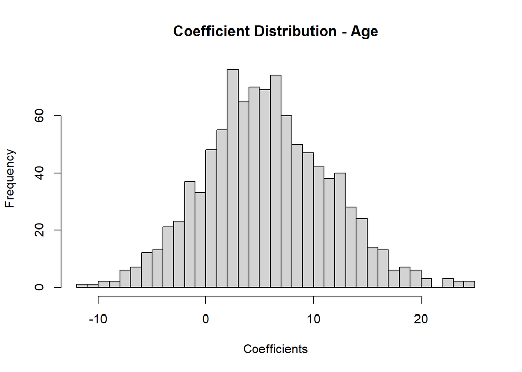

```r
hist(my_df$Age,
     breaks=30,
     xlab = "Coefficients", main = "Coefficient Distribution - Age")
```

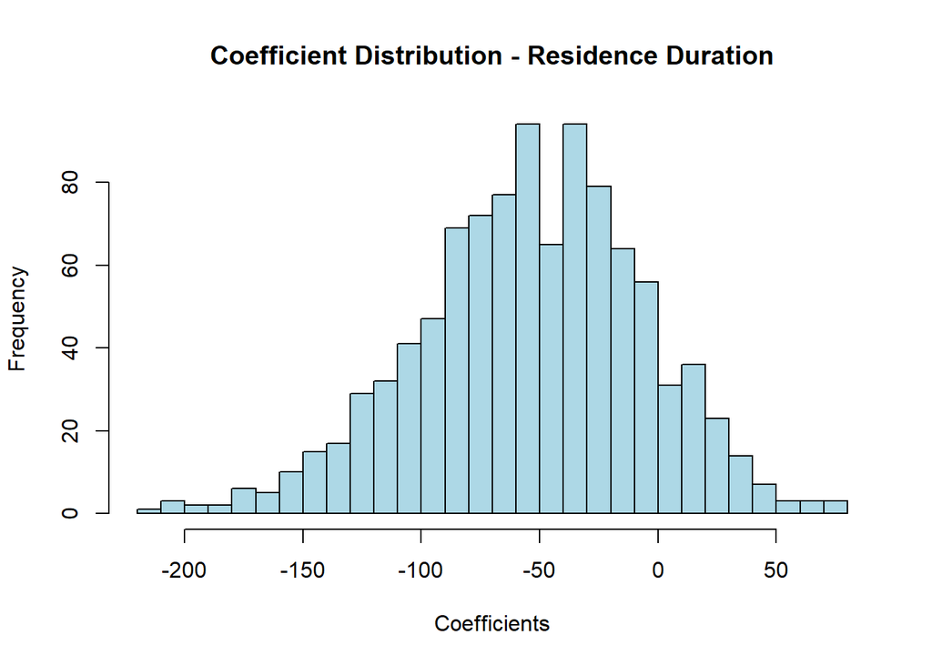

```r
hist(my_df$ResidenceDuration,
     breaks=30,
     xlab = "Coefficients", main = "Coefficient Distribution - Residence Duration", col="lightblue")
```

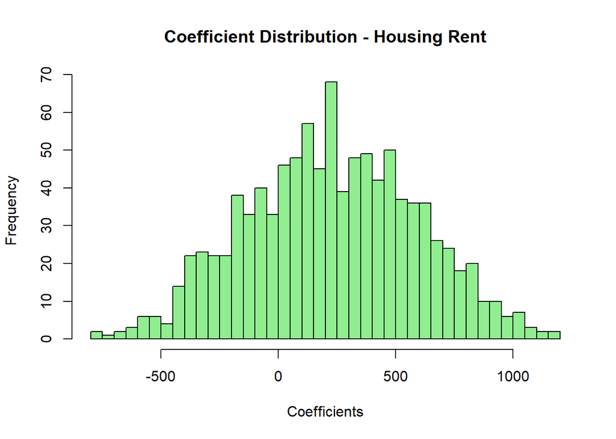

```r
hist(my_df$Housing.Rent,
     breaks=30,
     xlab = "Coefficients", main = "Coefficient Distribution - Housing Rent", col="lightgreen")
```

## Summary - Interpretation of Above Plots ~ all plots printed above are fairly normally distributed. See individual interpretations here:

### Age: the age coefficients are sometimes negatives which is the opposite of what I would normally think. Generally older people have higher credit, so seeing that the model sometimes says a higher age means a lesser loan is surprising. Overall the plot indicates age tends to have a positive impact on the loan amount, i.e., older people get higher loans.

### Residence Duration: this coefficient value is mostly negative meaning the longer someone resides in a location, the lower their predicted loan Amount. This may be because wealthier people who can get higher loans tend to move around more and can afford to move to new places. This matches expectations.

### Housing Rent: this coefficient value is mostly positive meaning the higher someone’s rent the higher their predicted loan amount tends to be. This makes sense is people who can afford more expensive living places will generally be approved for higher loans due to high credit scores and proof of income.

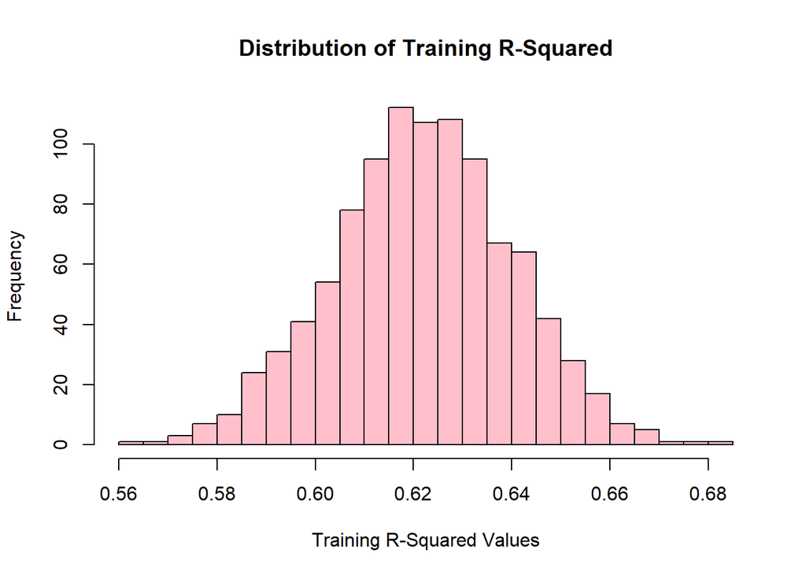

```r
hist(my_df$training_r2,
     breaks=30,
     xlab = "Training R-Squared Values", main = "Distribution of Training R-Squared", col="pink")
```

```r
mean(my_df$training_r2)
```

```
## [1] 0.6219217
```

```r
median(my_df$training_r2)
```

```
## [1] 0.6221699
```

```r
my_df <- my_df %>% mutate(r2_decrease = (training_r2 - holdout_r2)/training_r2)
head(my_df$r2_decrease, 5)
```

```
## [1] 0.08578634 0.05006284 0.12261069 0.26808393 0.02836774
```

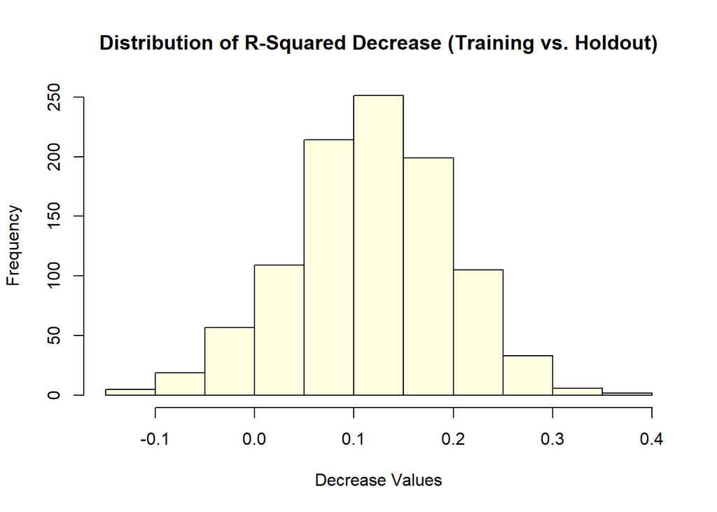

```r
hist(my_df$r2_decrease,
     breaks=12,
     xlab = "Decrease Values", main = "Distribution of R-Squared Decrease (Training vs. Holdout)",
     col="lightyellow")
```

```r
mean(my_df$r2_decrease)
```

```
## [1] 0.1170542
```

```r
median(my_df$r2_decrease)
```

```
## [1] 0.1206984
```

```r
print(my_df %>% dplyr::select(training_r2, holdout_r2, r2_decrease) %>% head(50))
```

```
##    training_r2 holdout_r2   r2_decrease
## 1    0.6178389  0.5648368  0.0857863355
## 2    0.6122784  0.5816260  0.0500628400
## 3    0.6231289  0.5467266  0.1226106867
## 4    0.6551495  0.4795145  0.2680839314
## 5    0.6012938  0.5842365  0.0283677370
## 6    0.6340567  0.5337269  0.1582346692
## 7    0.6188586  0.5557455  0.1019829975
## 8    0.6164051  0.5536415  0.1018220776
## 9    0.5982695  0.5985234 -0.0004245089
## 10   0.6397308  0.5176429  0.1908426374
## 11   0.6000028  0.5482957  0.0861780538
## 12   0.6037554  0.5803066  0.0388383056
## 13   0.6334589  0.5283196  0.1659765377
## 14   0.6173947  0.5658332  0.0835147594
```

[output cut: 36 more lines]

## Interpretation:

### These plots are also normally distributed and indicate that on average we can expect around a 12% percentage decrease from our training dataset R-squared of 62% to our holdout dataset. This means the model performs slightly worse on the holdout data. This is to be expected because this is unseen data – we just want the model to be able to generalize well, not necessarily have an excellent R-squared value. This is a good result.

```r
coefficient_means <- colMeans(my_df)
head(coefficient_means, 5)
```

```
##               (Intercept)                  Duration InstallmentRatePercentage
##               6514.445005                126.992393               -782.770921
##         ResidenceDuration                       Age
##                -53.757369                  5.662497
```

```r
coefficient_sds <- sapply(my_df, sd)
head(coefficient_sds, 5)
```

```
##               (Intercept)                  Duration InstallmentRatePercentage
##               1288.098431                  5.387694                 47.668309
##         ResidenceDuration                       Age
##                 47.748450                  5.836145
```

```r
# Difference between coefficient_means and actual model coefficients
bind <- data.frame(cbind(coefficient_means, save_coeff))
bind$abs_raw_diff <- abs(coefficient_means - save_coeff)
bind$percent_diff <- 100*abs(((coefficient_means - save_coeff) / save_coeff))

print(bind %>% na.omit())
```

```
##                                    coefficient_means    save_coeff abs_raw_diff
## (Intercept)                             6514.4450052  6787.3109335   272.865928
## Duration                                 126.9923926   121.7024620     5.289931
## InstallmentRatePercentage               -782.7709212  -803.3828621    20.611941
## ResidenceDuration                        -53.7573686    20.1154552    73.872824
## Age                                        5.6624968     1.4118155     4.250681
## NumberExistingCredits                     75.5933144     9.3048900    66.288424
## NumberPeopleMaintenance                 -207.9595145  -294.5123347    86.552820
## Telephone                               -478.1912394  -430.0143516    48.176888
## ForeignWorker                           -236.7257922  -174.4323728    62.293419
## CheckingAccountStatus.lt.0              -103.2913906    -0.3607945   102.930596
## CheckingAccountStatus.0.to.200           205.8951983   279.2494699    73.354272
## CheckingAccountStatus.gt.200            -616.6448860  -573.6950070    42.949879
## CreditHistory.NoCredit.AllPaid           849.4984033   508.5678641   340.930539
## CreditHistory.ThisBank.AllPaid           -47.9907468  -459.7257283   411.734981
## CreditHistory.PaidDuly                   -15.6668989   -61.1902427    45.523344
## CreditHistory.Delay                      113.9620829   138.9943540    25.032271
## Purpose.NewCar                         -1768.1136034 -2180.1076255   411.994022
## Purpose.UsedCar                        -1131.1941473 -1440.8553893   309.661242
## Purpose.Furniture.Equipment            -1851.4854148 -2295.6493157   444.163901
## Purpose.Radio.Television               -2085.7345008 -2454.9706733   369.236173
## Purpose.DomesticAppliance              -2481.7388581 -2559.0089901    77.270132
## Purpose.Repairs                        -1710.5724217 -1977.8988925   267.326471
## Purpose.Education                      -1907.1014641 -2429.6229301   522.521466
## Purpose.Business                       -1992.6396355 -2597.8420276   605.202392
## SavingsAccountBonds.lt.100              -329.4394441  -334.6707759     5.231332
## SavingsAccountBonds.100.to.500          -564.8601422  -201.3723119   363.487830
## SavingsAccountBonds.500.to.1000         -659.1950634  -769.0039648   109.808901
## SavingsAccountBonds.gt.1000             -386.4586074  -108.6142881   277.844319
## EmploymentDuration.lt.1                  114.2590421  -293.0847250   407.343767
## EmploymentDuration.1.to.4                 48.4814756   -89.4589353   137.940411
## EmploymentDuration.4.to.7                109.5993845  -200.9872948   310.586679
## EmploymentDuration.gt.7                 -159.3121487  -510.3288707   351.016722
## Personal.Male.Divorced.Seperated         480.5116417   503.3091425    22.797501
## Personal.Female.NotSingle                278.5919279   124.8996358   153.692292
## Personal.Male.Single                     735.2182940   892.2249404   157.006646
## OtherDebtorsGuarantors.None              129.5228933   133.9857097     4.462816
## OtherDebtorsGuarantors.CoApplicant       736.4230085   677.5142604    58.908748
## Property.RealEstate                     -837.7940304  -900.2620942    62.468064
## Property.Insurance                      -590.7038970  -511.6185864    79.085311
```

[output cut: 47 more lines]

```
## OtherDebtorsGuarantors.None            3.330815
## OtherDebtorsGuarantors.CoApplicant     8.694835
## Property.RealEstate                    6.938875
## Property.Insurance                    15.457865
## Property.CarOther                      6.498818
## OtherInstallmentPlans.Bank           584.922613
## OtherInstallmentPlans.Stores         107.728962
## Housing.Rent                          72.395714
## Housing.Own                           81.390417
## Job.UnemployedUnskilled                9.072845
## Job.UnskilledResident                  1.514303
## Job.SkilledEmployee                    9.240665
## training_r2                           99.990837
## holdout_r2                            99.549965
## r2_decrease                          100.014570
```

## Calculate Confidence Intervals & Width

```r
# Confidence Interval for Rep 1,000 Coefficients -------------------------------
# Transposed dataframe of confidence intervals for each variable
rep_conf <- data.frame(t(sapply(my_df[,1:63], function(x) Rmisc::CI(x, ci=0.95)))) #%>% na.omit()

# Calculate Width
# rep_conf$width <- (rep_conf$upper-rep_conf$lower)*sqrt(0.632)
rep_conf$width <- (rep_conf$upper-rep_conf$lower)*sqrt(0.632)

# MANUAL CHECK =============================
# Calculate Means
#means <- data.frame(means=sapply(my_df[1:61], function(x) mean(x)))
#n <- 1000
# Calculate Standard Deviation
#std_dev <- data.frame(std_dev=sapply(my_df[1:61], function(x) sd(x)))

#std_error <- std_dev / sqrt(n)
#alpha = 0.025
#degrees_of_freedom = n-1
#t_score = qt(p=alpha/2, df=degrees_of_freedom,lower.tail=F)
#margin_error <- t_score * std_error

#lower_bound_new <- means - margin_error
#upper_bound_new <- means + margin_error

#x <- cbind(lower_bound_new, upper_bound_new) %>% dplyr::rename(lower_new = 1, upper_new = 2)

#margin <- qnorm(0.975)*std
#rep_CI_low_manual <- means - margin
#rep_CI_high_manual <- means + margin
#manual <- cbind(rep_CI_low_manual, rep_CI_high_manual) %>%
#                dplyr::rename(lower_manual = 1, upper_manual = 2)


# =============================

# Reorder columns
rep_conf <- rep_conf %>% select(lower, upper, width)

# Keep only valid columns, remove R2 values
rep_conf <- rep_conf[1:61,]

# COMBINE for check
#z <- cbind(rep_conf, manual)
#z$width_manual <- z$upper_manual - z$lower_manual*sqrt(0.632)
#View(z)

# Check row count after ommitting NA
nrow(rep_conf)
```

```
## [1] 61
```

```r
# Confidence Interval for Full Model -------------------------------------------
# Calculate confidence interval and rename the columns
full_model_conf <- data.frame(confint(full_model, level=0.975)) %>%
                   #na.omit() %>%
                   dplyr::rename(lower_full = 1, upper_full = 2)

# Calculate Width
full_model_conf <- full_model_conf %>%
                   #mutate(index=1:nrow(full_model_conf)) %>%
                   #filter(index %in% (2:48)) %>%
                   mutate(width_full=upper_full-lower_full)

# Check row count
nrow(full_model_conf)
```

```
## [1] 61
```

```r
#t <- cbind(rep_conf, full_model_conf)

row.names(rep_conf) == row.names(full_model_conf)
```

```
##  [1] TRUE TRUE TRUE TRUE TRUE TRUE TRUE TRUE TRUE TRUE TRUE TRUE TRUE TRUE TRUE
## [16] TRUE TRUE TRUE TRUE TRUE TRUE TRUE TRUE TRUE TRUE TRUE TRUE TRUE TRUE TRUE
## [31] TRUE TRUE TRUE TRUE TRUE TRUE TRUE TRUE TRUE TRUE TRUE TRUE TRUE TRUE TRUE
## [46] TRUE TRUE TRUE TRUE TRUE TRUE TRUE TRUE TRUE TRUE TRUE TRUE TRUE TRUE TRUE
## [61] TRUE
```

```r
#View(cbind(row.names(rep_conf), row.names(full_model_conf)))
```

## Determine how many of the repeated sample CI’s are tighter

```r
# Combine the 2 dataframes and remove NA values
calc <- cbind(rep_conf, full_model_conf) %>% na.omit()

#Calculate how many of the repeated sample CI’s are tighter or broader than the full model CI’s. If the #width is smaller, the CI is tighter. If the width is bigger, the CI is broader.

# 1 means the CI is tighter (width of repeated is smaller)
calc$tighter_CI_flag <- ifelse(calc$width < calc$width_full, 1, 0)

print(calc)
```

```
##                                           lower        upper       width
## (Intercept)                         6434.512462  6594.377548 127.0902300
## Duration                             126.658061   127.326724   0.5315769
## InstallmentRatePercentage           -785.728963  -779.812879   4.7031936
## ResidenceDuration                    -56.720384   -50.794353   4.7111008
## Age                                    5.300337     6.024657   0.5758232
## NumberExistingCredits                 69.363798    81.822830   9.9047346
## NumberPeopleMaintenance             -216.003986  -199.915043  12.7904564
## Telephone                           -485.081845  -471.300634  10.9558456
## ForeignWorker                       -252.202656  -221.248928  24.6077270
## CheckingAccountStatus.lt.0          -111.010789   -95.571992  12.2736005
## CheckingAccountStatus.0.to.200       198.371108   213.419289  11.9630674
## CheckingAccountStatus.gt.200        -625.443188  -607.846584  13.9890232
## CreditHistory.NoCredit.AllPaid       828.778975   870.217831  32.9432387
## CreditHistory.ThisBank.AllPaid       -63.992056   -31.989438  25.4415777
## CreditHistory.PaidDuly               -23.562737    -7.771061  12.5541347
## CreditHistory.Delay                  101.276790   126.647376  20.1692174
## Purpose.NewCar                     -1838.362958 -1697.864249 111.6942644
## Purpose.UsedCar                    -1201.222149 -1061.166146 111.3423206
## Purpose.Furniture.Equipment        -1921.369565 -1781.601264 111.1136015
## Purpose.Radio.Television           -2155.367272 -2016.101729 110.7139173
## Purpose.DomesticAppliance          -2554.168943 -2409.308773 115.1615578
## Purpose.Repairs                    -1782.423125 -1638.721719 114.2403585
## Purpose.Education                  -1977.357123 -1836.845805 111.7042881
## Purpose.Business                   -2063.524192 -1921.755079 112.7042160
## SavingsAccountBonds.lt.100          -338.218770  -320.660118  13.9588517
## SavingsAccountBonds.100.to.500      -575.839300  -553.880984  17.4565155
## SavingsAccountBonds.500.to.1000     -671.130904  -647.259223  18.9776114
## SavingsAccountBonds.gt.1000         -398.022327  -374.894888  18.3859508
## EmploymentDuration.lt.1               94.460578   134.057506  31.4789355
## EmploymentDuration.1.to.4             28.761788    68.201164  31.3536839
## EmploymentDuration.4.to.7             89.356428   129.842341  32.1856648
## EmploymentDuration.gt.7             -178.787313  -139.836985  30.9648983
## Personal.Male.Divorced.Seperated     465.074755   495.948528  24.5441640
## Personal.Female.NotSingle            270.520761   286.663095  12.8329019
## Personal.Male.Single                 726.710725   743.725863  13.5267668
## OtherDebtorsGuarantors.None          119.128733   139.917054  16.5263880
## OtherDebtorsGuarantors.CoApplicant   718.892800   753.953217  27.8724802
## Property.RealEstate                 -856.026216  -819.561845  28.9886012
## Property.Insurance                  -609.422988  -571.984806  29.7627661
```

[output cut: 89 more lines]

```
## Personal.Male.Divorced.Seperated                 1
## Personal.Female.NotSingle                        1
## Personal.Male.Single                             1
## OtherDebtorsGuarantors.None                      1
## OtherDebtorsGuarantors.CoApplicant               1
## Property.RealEstate                              1
## Property.Insurance                               1
## Property.CarOther                                1
## OtherInstallmentPlans.Bank                       1
## OtherInstallmentPlans.Stores                     1
## Housing.Rent                                     1
## Housing.Own                                      1
## Job.UnemployedUnskilled                          1
## Job.UnskilledResident                            1
## Job.SkilledEmployee                              1
```

```r
percent <- sum(calc$tighter_CI_flag)/nrow(calc)
print(percent*100)
```

```
## [1] 100
```

```r
sum(calc$tighter_CI_flag)
```

```
## [1] 47
```

## Conclusion: 100% of the simulated/repeated model’s CI’s are tighter/smaller. In other words, of the 47 columns left after removing NA’s and the class column, 47 of the columns’ confidence intervals from the repeated samples are smaller/tighter than those comapred to the CI’s from the full model.

## This tells us that when we repeat the model 1,000 times, the confidence in the best coefficients for each independent variable has increased (the range of our confidence intervals are smaller). Intuitively this makes sense because instead of just running 1 model and trying to fit the best coefficients, we have now done this 1,000 times and taken averages to make this determination. If we were to sample 10,000 times, the confidence intervals would be even tighter. There should be convergence at some point (diminishing returns), but there will be an improvement event passed 1,000.

## In many instances, the repeated model’s coefficient means were quite different from the single model we saved the coefficients for. The median difference between the repeated model mean and the corresponding saved model coefficients was 21.5%. This tells us that running just 1 model does not accurately capture what we can assume would be a “better” coefficient to use – models should be run multiples time to find the optimal fit.